# 1-phase CSI

The single-phase current source inverter given below is operated such that the current through the RC load is a $1\,$kHz square wave. What is the peak magnitude of the voltage $V_{AB}$ across the load?

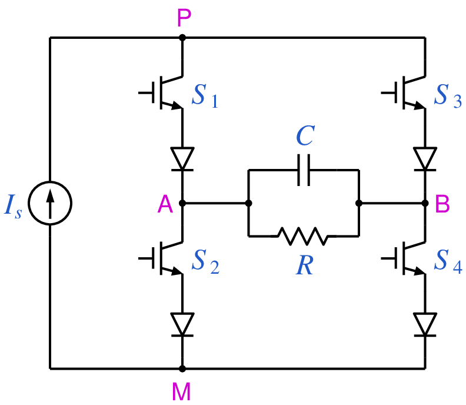

```python
from IPython.display import Image
Image(filename =r'CSI_1ph_1_fig_1.png', width=300)
```

```python
# run this cell to view the circuit file.
%pycat CSI_1ph_1_orig.in
```

We now replace the strings such as \$Idc, \$R, with the values of our choice by running the python script given below. It takes an existing circuit file `CSI_1ph_1_orig.in` and produces a new circuit file `CSI_1ph_1.in`, after replacing \$Idc, \$R, etc. with values of our choice.

```python
import gseim_calc as calc
s_Idc = '10'
s_R = '100'
s_C = '10e-6'

s_f_hz = "1.0e3"
f_hz = float(s_f_hz)

T = 1/f_hz
s_Tby2 = "%11.4E"%(T/2)

l = [
  ('$Idc', s_Idc),
  ('$R', s_R),
  ('$C', s_C),
  ('$f_hz', s_f_hz),
  ('$Tby2', s_Tby2)
]
calc.replace_strings_1("CSI_1ph_1_orig.in", "CSI_1ph_1.in", l)
print('CSI_1ph_1.in is ready for execution')
```

```
CSI_1ph_1.in is ready for execution
```

**Execute the following cell to run GSEIM on CSI_1ph_1.in.**

```python
import os
import dos_unix
# uncomment for windows:
#dos_unix.d2u("CSI_1ph_1.in")
os.system('run_gseim CSI_1ph_1.in')
```

```
Circuit: filename = CSI_1ph_1.in
main: calling solve_sss
solve_sss starting: sss_n_st: 1
solve_sss_ex: sss_iter_newton=0, rhs_sss_norm=2.1099e-03, sss_period_1_compute=2.0000e-03
solve_sss_ex: sss_iter_newton=1, rhs_sss_norm=2.4191e-10, sss_period_1_compute=2.0000e-03
solve_sss_ex: sss_iter_newton=2, rhs_sss_norm=5.6379e-18, sss_period_1_compute=2.0000e-03
solve_sss_ex: calling sss_solve_trns_ex for one more trns step
Transient simulation starts...
i=0
i=1000
GSEIM: Program completed.
```

```
0
```

The circuit file (`CSI_1ph_1.in`) is created in the same directory as that used for launching Jupyter notebook. The last step (i.e., running `GSEIM` on `CSI_1ph_1.in`) creates a data file called `CSI_1ph_1.dat`in the same directory. We can now use the python code below to compute/plot the various quantities of interest.

```
filename: CSI_1ph_1.dat
max(V_AB):  2.4468E+02
```

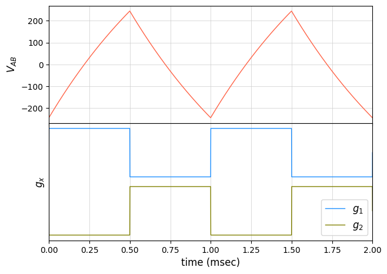

```python
import numpy as np
import matplotlib.pyplot as plt
import gseim_calc as calc
from setsize import set_size

slv = calc.slv("CSI_1ph_1.in")

i_slv = 0
i_out = 0
filename = slv.l_filename_all[i_slv][i_out]
print('filename:', filename)
u = np.loadtxt(filename)
t = u[:, 0]

v_out = slv.get_array_double(i_slv,i_out,"v_out", u)
g1    = slv.get_array_double(i_slv,i_out,"g1",    u)
g2    = slv.get_array_double(i_slv,i_out,"g2",    u)
IS1   = slv.get_array_double(i_slv,i_out,"IS1",   u)
IS2   = slv.get_array_double(i_slv,i_out,"IS2",   u)
IS3   = slv.get_array_double(i_slv,i_out,"IS3",   u)
IS4   = slv.get_array_double(i_slv,i_out,"IS4",   u)
Iload = slv.get_array_double(i_slv,i_out,"Iload", u)

# get f_hz from the circuit file:

f_in = open("CSI_1ph_1.in", "r")
for line in f_in:
    if 'name=clock1' in line:
        for s in line.split():
            if s.startswith('f_hz='):
                f_hz = float(s.split('=')[1])
f_in.close()

T = 1/f_hz

l1 = calc.min_max_1(t, v_out, 0.0, 2.0*T)
print('max(V_AB):', "%11.4E"%l1[1])

fig, ax = plt.subplots(2, sharex=False)
plt.subplots_adjust(wspace=0, hspace=0.0)

set_size(5.5, 4, ax[0])

for i in range(2):
    ax[i].set_xlim(left=0.0, right=2.0*T*1e3)
    ax[i].grid(color='#CCCCCC', linestyle='solid', linewidth=0.5)

ax[0].set_ylabel(r'$V_{AB}$', fontsize=12)
ax[1].set_ylabel(r'$g_x$'   , fontsize=12)

ax[0].tick_params(labelbottom=False)

color1 = "tomato"
color2 = "dodgerblue"
color3 = "olive"

ax[0].plot(t*1e3, v_out, color=color1, linewidth=1.0, label="$V_{AB}$")

ax[1].plot(t*1e3, (g1      ), color=color2, linewidth=1.0, label="$g_1$")
ax[1].plot(t*1e3, (g2 - 1.2), color=color3, linewidth=1.0, label="$g_2$")

ax[1].set_xlabel('time (msec)', fontsize=12)
ax[1].tick_params(left = False)
ax[1].set_yticks([])

ax[1].legend(loc = 'lower right',frameon = True, fontsize = 10, title = None,
  markerfirst = True, markerscale = 1.0, labelspacing = 0.5, columnspacing = 2.0,
  prop = {'size' : 12})

#plt.tight_layout()
plt.show()
```

This notebook was contributed by **Prof. Nakul Narayanan K**, Govt. Engineering College, Thrissur. He may be contacted at nakul@gectcr.ac.in.